# Data Science Capstone - Milestone Report

Sérgio Fernandes

6/6/2018

## Library Assigments

```r
knitr::opts_chunk$set(echo = TRUE)
library(tm) # Text Mining Library
```

```r
library(SnowballC) # Provides wordStem() for stemming.
library(RColorBrewer) # Generate palette of colours for plots.
library(ggplot2) # Plot word frequencies.
library(magrittr)
library(Hmisc)
library(stringi)# For character string analysis
library(wordcloud) # Plot Word Cloud
library(RWeka) # Machine LEarning Tools written in Java
library(rJava) # Support for java written packages
```

## Read US Data

Only US data is needed once in this case addressing only one language is enough for the project

```r
knitr::opts_chunk$set(echo = TRUE)

 blog <- readLines("C:\\CapstoneProject\\en_US\\en_US.blogs.txt", encoding="UTF-8", skipNul = TRUE)
 news <- readLines("C:\\CapstoneProject\\en_US\\en_US.news.txt", encoding="UTF-8", skipNul = TRUE)
 twitter <- readLines("C:\\CapstoneProject\\en_US\\en_US.twitter.txt", encoding="UTF-8", skipNul = TRUE)
```

## Exploratory Data Analysis

### Basic Statistics about readen data

```r
knitr::opts_chunk$set(echo = TRUE)

 stri_stats_general(blog)
```

```
##       Lines LinesNEmpty       Chars CharsNWhite
##      899288      899288   206824382   170389539
```

```r
 stri_stats_general(news)
```

```
##       Lines LinesNEmpty       Chars CharsNWhite
##       77259       77259    15639408    13072698
```

```r
 stri_stats_general(twitter)
```

```
##       Lines LinesNEmpty       Chars CharsNWhite
##     2360148     2360148   162096241   134082806
```

## Spliting data in Training and Test data

Data randoomly split in Train Data, used to train models and Test Data used to Test model accuracy in proportions of 60% for training and 40% for Test.

```r
knitr::opts_chunk$set(echo = TRUE)
 #Randomly permute the order of lines in the files for splitting
set.seed(310)
blog <- blog[sample(seq(length(blog)))]
news <- news[sample(seq(length(news)))]
twitter <- twitter[sample(seq(length(twitter)))]

#Split the blog text
n <- length(blog)
train.blog <- blog[1:floor(n*0.6)]
test.blog <- blog[(floor(n*0.6)+1):n]
#Split the news text
n <- length(news)
train.news <- news[1:floor(n*0.6)]
test.news <- news[(floor(n*0.6)+1):n]
#Split the twitter text
n <- length(twitter)
train.twit <- twitter[1:floor(n*0.6)]
test.twit <- twitter[(floor(n*0.6)+1):n]



save(train.blog, file = "C:\\CapstoneProject\\TrainData\\train.blog.txt")
save(train.news, file = "C:\\CapstoneProject\\TrainData\\train.news.txt")
save(train.twit, file = "C:\\CapstoneProject\\TrainData\\train.twit.txt")

save(test.blog, file = "C:\\CapstoneProject\\TestData\\test.blog.txt")
save(test.news, file = "C:\\CapstoneProject\\TestData\\test.news.txt")
save(test.twit, file = "C:\\CapstoneProject\\TestData\\test.twit.txt")
```

## Apply Transformations - Data Cleansing

Some transformations are then applied to Train and Test data, including: - Remove of special characters - Covert to Lower case - Remove Punctuation - Remove some stop words from English dictionary and some provided here in code - Remove numbers, white spaces and some English endings according to provided dictionary (from tool)

```r
knitr::opts_chunk$set(echo = TRUE)

cname <- file.path("C:\\CapstoneProject\\TrainData")
TrainData <- Corpus(DirSource(cname))

toSpace <- content_transformer(function(x, pattern) gsub(pattern, " ", x))
TrainData <- tm_map(TrainData, toSpace, "/|@|//|$|:|:)|*|&|!|?|_|-|#|¬o")  ## replace special characters by space
TrainData <- tm_map(TrainData, content_transformer(tolower)) # Conversion to Lower Case
TrainData <- tm_map(TrainData, removePunctuation) # Punctuation can provide gramatical context which supports
TrainData <- tm_map(TrainData, removeWords, stopwords("english")) # common stop Words like for, very, and, of, are, etc,
TrainData <- tm_map(TrainData, removeWords, c("the", "will", "The", "also", "that", "and", "for", "in", "is", "it", "not", "to"))
TrainData <- tm_map(TrainData, removeNumbers) # removal of numbers
TrainData <- tm_map(TrainData, stripWhitespace) # removal of whitespace
TrainData <- tm_map(TrainData, stemDocument) # Stemming uses an algorithm that removes common word endings for English


cname <- file.path("C:\\CapstoneProject\\TestData")
TestData <- Corpus(DirSource(cname))

toSpace <- content_transformer(function(x, pattern) gsub(pattern, " ", x))
TestData <- tm_map(TestData, toSpace, "/|@|//|$|:|:)|*|&|!|?|_|-|#|¬o")  ## replace special characters by space
TestData <- tm_map(TestData, content_transformer(tolower)) # Conversion to Lower Case
TestData <- tm_map(TestData, removePunctuation) # Punctuation can provide gramatical context which supports
TestData <- tm_map(TestData, removeWords, stopwords("english")) # common stop Words like for, very, and, of, are, etc,
TestData <- tm_map(TestData, removeWords, c("the", "will", "The", "also", "that", "and", "for", "in", "is", "it", "not", "to"))
TestData <- tm_map(TestData, removeNumbers) # removal of numbers
TestData <- tm_map(TestData, stripWhitespace) # removal of whitespace
TestData <- tm_map(TestData, stemDocument) # Stemming uses an algorithm that removes common word endings for English


dtm <- DocumentTermMatrix(TrainData)
dtm
```

```
## <<DocumentTermMatrix (documents: 3, terms: 17394)>>
## Non-/sparse entries: 22247/29935
## Sparsity           : 57%
## Maximal term length: 42
## Weighting          : term frequency (tf)
```

```r
tdm <- TermDocumentMatrix(TrainData)
tdm
```

```
## <<TermDocumentMatrix (terms: 17394, documents: 3)>>
## Non-/sparse entries: 22247/29935
## Sparsity           : 57%
## Maximal term length: 42
## Weighting          : term frequency (tf)
```

## Final Exploratory Data Analysis

In this section some exploratory data Analysis is performed, consisting in: - Frequencies - Worcloud, providing count of words in a visual way - Cloud - Ngrams - Uni, bi and tri grams of data and respective frequency

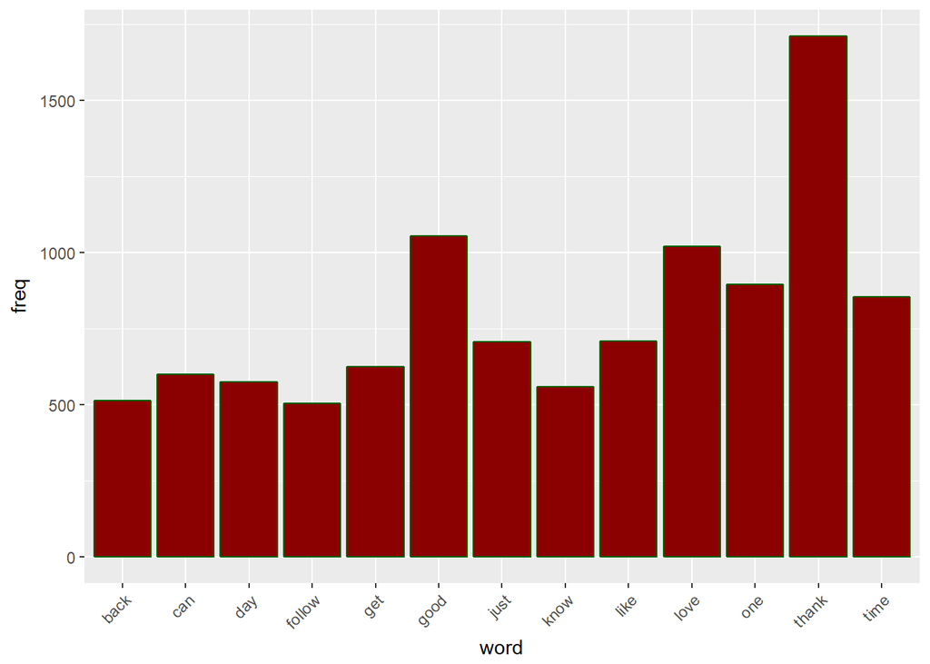

```r
knitr::opts_chunk$set(echo = TRUE)
# Frequency
freq <- sort(colSums(as.matrix(dtm)), decreasing=TRUE)
wf <- data.frame(word=names(freq), freq=freq)
# Plot Histogram
subset(wf, freq>500)    %>%
        ggplot(aes(word, freq)) +
        geom_bar(stat="identity", fill="darkred", colour="darkgreen") +
        theme(axis.text.x=element_text(angle=45, hjust=1))
```

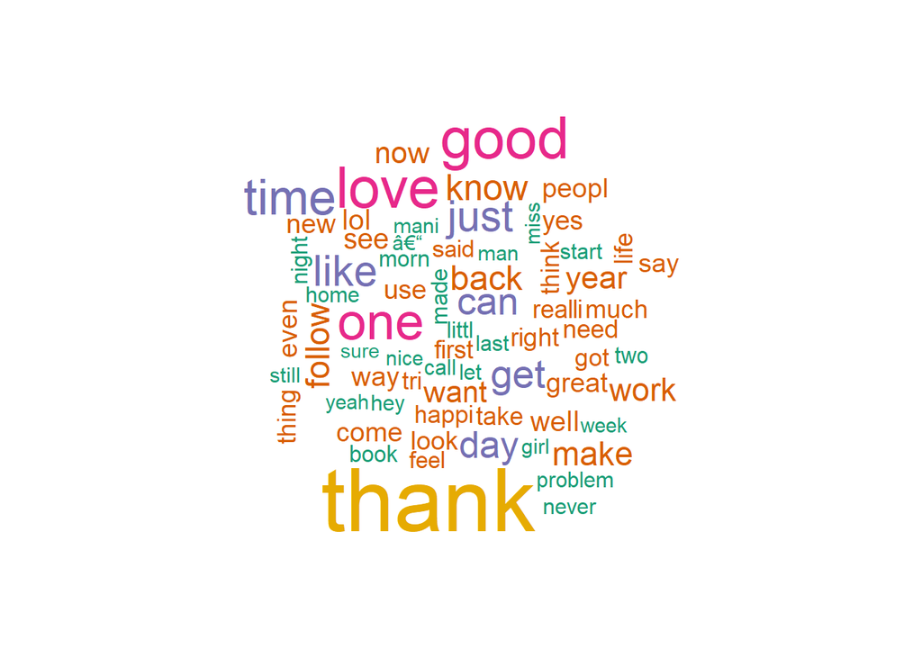

```r
library(wordcloud)
set.seed(100)
wordcloud(names(freq), freq, min.freq=200, colors=brewer.pal(6, "Dark2"))
```

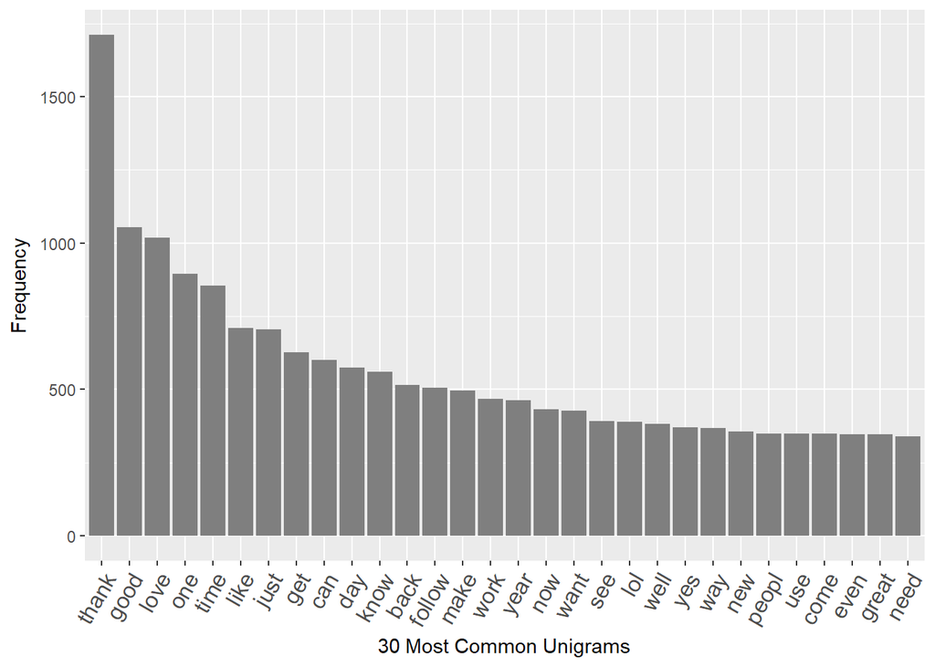

```r
options(mc.cores=1)

getFreq <- function(tdm) {
  freq <- sort(rowSums(as.matrix(tdm)), decreasing = TRUE)
  return(data.frame(word = names(freq), freq = freq))
}
bigram <- function(x) NGramTokenizer(x, Weka_control(min = 2, max = 2))
trigram <- function(x) NGramTokenizer(x, Weka_control(min = 3, max = 3))
makePlot <- function(data, label) {
  ggplot(data[1:30,], aes(reorder(word, -freq), freq)) +
         labs(x = label, y = "Frequency") +
         theme(axis.text.x = element_text(angle = 60, size = 12, hjust = 1)) +
         geom_bar(stat = "identity", fill = I("grey50"))
}

# Get frequencies of most common n-grams in data sample
freq1 <- getFreq(removeSparseTerms(TermDocumentMatrix(TrainData), 0.9999))
freq2 <- getFreq(removeSparseTerms(TermDocumentMatrix(TrainData, control = list(tokenize = bigram)), 0.9999))
freq3 <- getFreq(removeSparseTerms(TermDocumentMatrix(TrainData, control = list(tokenize = trigram)), 0.9999))

makePlot(freq1, "30 Most Common Unigrams")
```

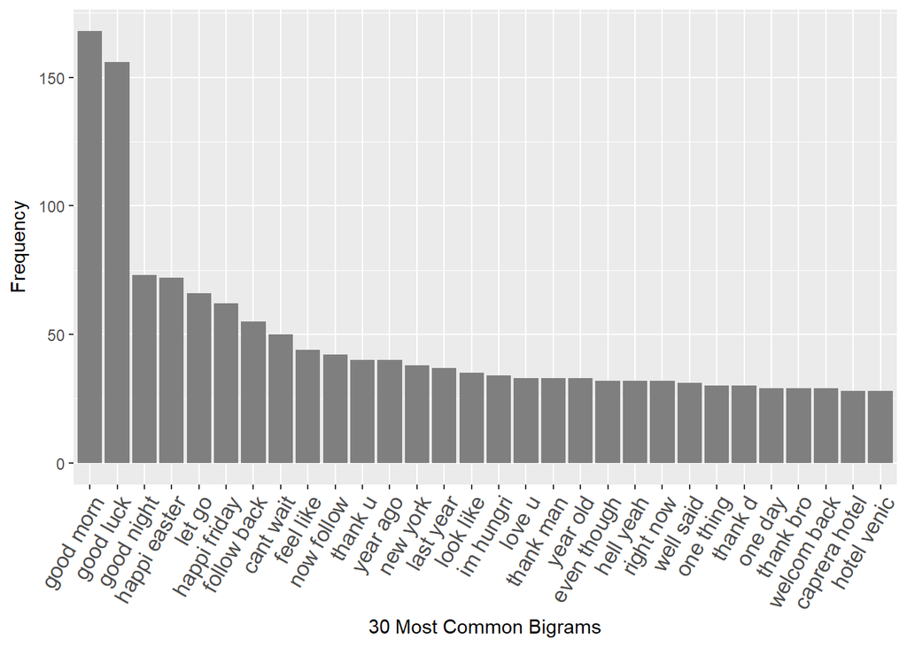

```r
makePlot(freq2, "30 Most Common Bigrams")
```

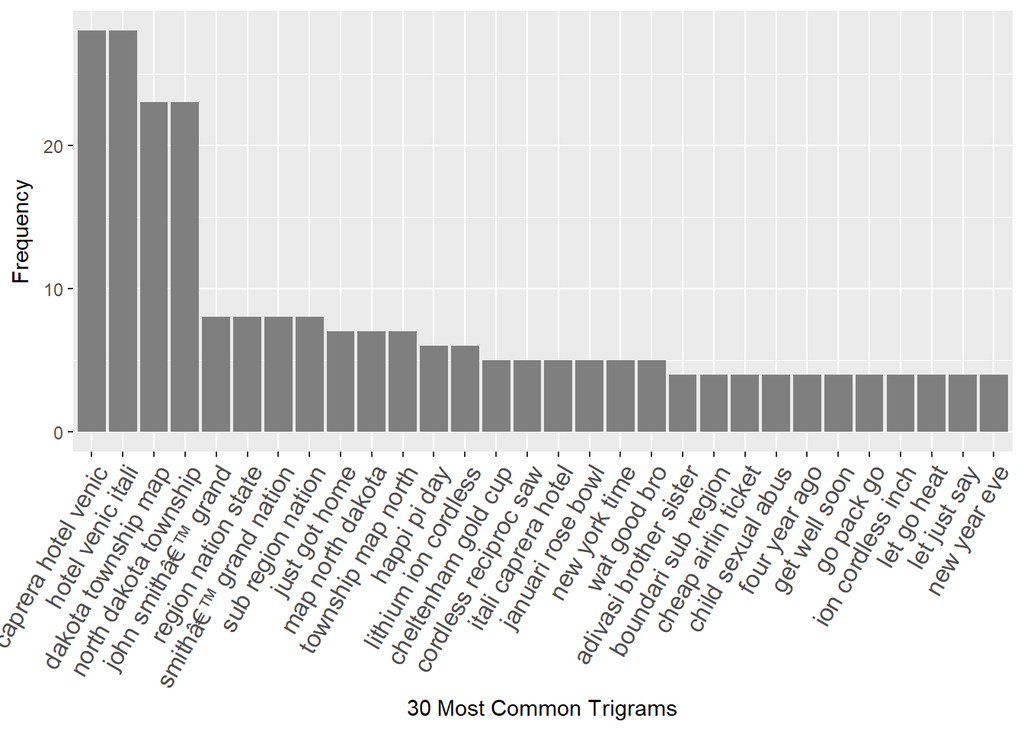

```r
makePlot(freq3, "30 Most Common Trigrams")
```

## Next Steps

This work can now be used as a skeleton for Final Capstone Project, using cleaned Train and Test data to apply models and build shiny application